# Analiza statystyczna współzależności indeksów RUT i IXIC

Marcel Radwański, Paweł Szulik

2026-03-24

# Opis projektu

Celem projektu jest zbadanie statystycznych zależności pomiędzy dwoma kluczowymi indeksami amerykańskiego rynku kapitałowego: **Russell 2000 (RUT)** oraz **NASDAQ Composite (IXIC)**. Analiza wykorzystuje wartości indeksów od początku 2008 roku, dzięki czemu uwzględnienia zmiany wywołane m.in. przez kryzys finansowy w 2008.

## Wykorzystane indeksy

- **Russell 2000 (RUT)**: Indeks reprezentujący 2000 spółek o małej kapitalizacji.Jest on uważany za barometr kondycji wewnętrznej gospodarki USA.
- **NASDAQ Composite (IXIC)**: Szeroki indeks obejmujący spółki notowane na giełdzie NASDAQ. Jest to indeks ważony kapitalizacją rynkową: większe firmy mają większy wpływ na jego wartość.

## Przygotowanie danych

```r
library(tidyverse)
library(dplyr)

# Wczytanie danych

RUT <- read.csv("data/RUT.csv")
IXIC <-read.csv("data/IXIC.csv")

# Wybranie dat występujących w obu zbiorach

RUT <- RUT[RUT$date %in% IXIC$date, ]
IXIC <- IXIC[IXIC$date %in% RUT$date, ]

# Obliczenie dziennych stóp zwrotu

RUT$return <- c(NA, diff(RUT$close) / RUT$close[-length(RUT$close)])
IXIC$return <- c(NA, diff(IXIC$close) / IXIC$close[-length(IXIC$close)])

# Czyszczenie danych
RUT <- RUT %>%
  select(date, close, return) %>%
  filter(date >= "2008-01-01")
IXIC <- IXIC %>%
  select(date, close, return) %>%
  filter(date >= "2008-01-01")
```

# Testy permutacyjne

```r
n <- 5000
```

## Istotność kowariancji

Test sprawdza, czy zaobserwowana kowariancja między indeksami jest wynikiem rzeczywistego powiązania, czy dziełem przypadku.

H<sub>0</sub>: Zmienne są niezależne.

```r
cov_ret <- cov(RUT$return, IXIC$return) # Faktyczna kowariancja z danych historycznych
cov_perm <- replicate(n, cov(RUT$return, sample(IXIC$return))) # Losowe mieszanie zwrotów z indeksu IXIC
p_val_cov <- sum(abs(cov_perm) >= abs(cov_ret)) / n # Obliczamy p-value (test dwustronny): ile razy losowa kowariancja była silniejsza niż realna

cat("Zaobserwowana kowariancja:", cov_ret)
```

```
## Zaobserwowana kowariancja: 0.0002014181
```

```r
cat("\nP-value:", p_val_cov)
```

```
##
## P-value: 0
```

Wniosek: Odrzucamy H<sub>0</sub> - zależność indeksów RUT i IXIC jest statystycznie istotna.

## Test równości wariancji i wartości oczekiwanych

```r
pool <- c(RUT$return, IXIC$return) # Łączymy stopy zwrotu obu indeksów w jedną pulę danych
n_rut <- length(RUT$return)
n_total <- length(pool)
```

### Test równości wariancji

Test sprawdza, czy dane są równo rozproszone wokół średniej w obu zbiorach.

```r
v_rut <- var(RUT$return)
v_ixic <- var(IXIC$return)
obs_var_ratio <- max(v_rut, v_ixic) / min(v_rut, v_ixic) # Wyznaczamy faktyczny stosunek wariancji (większa do mniejszej)

var_ratios_perm <- replicate(n, {
  shuffled <- sample(pool) # Mieszamy wszystkie obserwacje z połączonej puli danych
  v1 <- var(shuffled[1:n_rut]) # Obliczamy wariancję dla pierwszej losowo wybranej grupy
  v2 <- var(shuffled[(n_rut + 1):n_total]) # Obliczamy wariancję dla pozostałych danych
  max(v1, v2) / min(v1, v2) # Obliczamy stosunek wariancji konkretnego losowania
})

p_val_var <- sum(var_ratios_perm >= obs_var_ratio) / n # p-value = odsetek losowych stosunków większych od zaobserwowanego

cat("\nZaobserwowany stosunek wariancji:", obs_var_ratio)
```

```
##
## Zaobserwowany stosunek wariancji: 1.27217
```

```r
cat("\nP-value:", p_val_var)
```

```
##
## P-value: 0
```

Wniosek: Odrzucamy H<sub>0</sub> - indeksy różnią się istotnie wariancją.

### Test równości wartości oczekiwanych

Test sprawdza, czy średnie stopy zwrotu są statystycznie takie same.

```r
obs_mean_diff <- abs(mean(RUT$return) - mean(IXIC$return))

mean_diffs_perm <- replicate(n, {
  shuffled <- sample(pool) # Mieszamy wszystkie obserwacje z połączonej puli danych
  m1 <- mean(shuffled[1:n_rut]) # Obliczamy średnią dla pierwszej losowej grupy
  m2 <- mean(shuffled[(n_rut + 1):n_total]) # Obliczamy średnią dla drugiej losowej grupy
  abs(m1 - m2) # Obliczamy bezwzględną różnicę średnich dla tego losowania
})

p_val_mean <- sum(mean_diffs_perm >= obs_mean_diff) / n # p-value = odsetek losowych różnic większych od zaobserwowanej

cat("\nZaobserwowana różnica średnich:", obs_mean_diff)
```

```
##
## Zaobserwowana różnica średnich: 0.0001730628
```

```r
cat("\nP-value:", p_val_mean, "\n")
```

```
##
## P-value: 0.5942
```

Wniosek: Brak podstaw do odrzucenia H<sub>0</sub> - średnie zyski są zbliżone.

# Symulacja strategii inwestycyjnej

```r
n <- nrow(RUT)
dni_trzymanie <- 100
liczba_akcji <- 100

zysk_portfel <- numeric(n - dni_trzymanie)

for (i in 1:(n - dni_trzymanie)){
  zysk_RUT <- (RUT$close[i + dni_trzymanie] - RUT$close[i]) * liczba_akcji

  zysk_IXIC <- (IXIC$close[i + dni_trzymanie] - IXIC$close[i]) * liczba_akcji

  zysk_portfel[i] <- zysk_RUT + zysk_IXIC
}
```

Dla naszej potencjalnej strategii inwestycyjnej zakładamy, że każdego dnia kupujemy po 100 akcji danego indeksu, które sprzedajemy 100 dni od zakupu. Przygotowujemy pusty wektor, który będzie przechowywał zysk z każdego dnia. Jest on krótszy o 100 wartości niż liczba obserwacji, ponieważ nie znamy cen sprzedaży dla ostatnich 100 zakupów. Przeprowadzamy symulację, gdzie dla każdego indeksu **zysk = (cena sprzedaży - cena zakupu) * liczba akcji**, a zysk portfela to sumaryczny zysk z obu instrumentów.

## Histogram zysku portfela

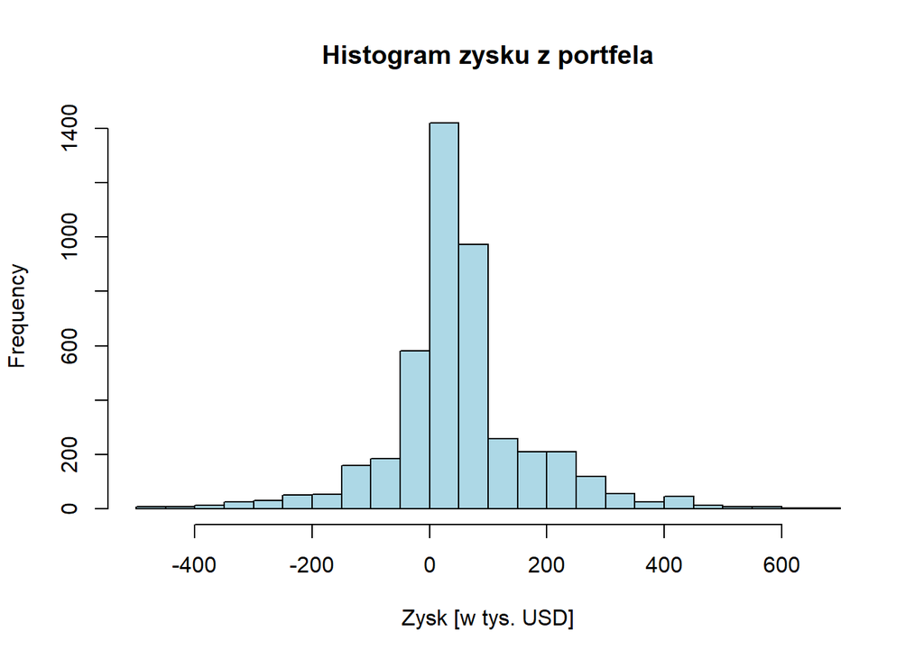

```r
hist(zysk_portfel / 1000, breaks = 30, col = 'lightblue',
     main = "Histogram zysku z portfela",
     xlab = "Zysk [w tys. USD]",
     )
```

Tworzymy wykres, który pokazuje rozkład dziennych zysków z inwestycji.

## Test normalności

```r
shapiro.test(zysk_portfel)
```

```
##
##  Shapiro-Wilk normality test
##
## data:  zysk_portfel
## W = 0.91347, p-value < 2.2e-16
```

```r
cat("p-value < 2.2e-16")
```

```
## p-value < 2.2e-16
```

```r
cat("WNIOSEK: ROZKŁAD ZYSKU Z PORTFELA NIE JEST OPISANY ROZKŁADEM NORMALNYM")
```

```
## WNIOSEK: ROZKŁAD ZYSKU Z PORTFELA NIE JEST OPISANY ROZKŁADEM NORMALNYM
```

Przeprowadam test Shapiro-Wilka, aby sprawdzić, czy rozkład zysku jest rozkładem normalnym. P-value jest znacząco mniejsze od 0.05 => Zysk nie ma rozkładu normalnego.

## Value at Risk (VaR)

```r
# historyczny
poziomy_istotnosci <- c(0.05, 0.01, 0.001)
var_historyczny <- quantile(zysk_portfel, poziomy_istotnosci)

# normalny (parametryczny)
srednia_portfel <- mean(zysk_portfel)
sd_portfel<-sd(zysk_portfel)
var_norm <- qnorm(poziomy_istotnosci, srednia_portfel, sd_portfel)

# porownanie VaR
var_porownanie <- data.frame(
  Historyczny = var_historyczny,
  Normalny = var_norm
)

print(var_porownanie)
```

```
##      Historyczny  Normalny
## 5%     -131380.4 -156088.9
## 1%     -315095.9 -241744.8
## 0.1%   -469512.2 -337756.2
```

```r
cat("Przy poziomie istotności 5%, VaR historyczny jest większy niż normalny,
    jednakże przy 1% i 0.1% VaR historyczny już jest znacznie niższy od normalnego,
    co pokazuje, że traciliśmy więcej niż zakładał rozkład normalny. ")
```

```
## Przy poziomie istotności 5%, VaR historyczny jest większy niż normalny,
##     jednakże przy 1% i 0.1% VaR historyczny już jest znacznie niższy od normalnego,
##     co pokazuje, że traciliśmy więcej niż zakładał rozkład normalny.
```

Obliczam Value at Risk dla zysku czyli maksymalną wartość zysku, którą mogę stracić, przy danym prawdopodobieństwie. Na początku używam do tego danych historycznych, za poziomy istotności przyjmuję **5%, 1% i 0.1%**. Następnie dla tych samych poziomów istotności obliczam VaR normalny, czyli sprawdzam, co by się stało, gdyby traktować mój rozkład, jako rozkład normalny, z niezmienionymi wartościami średniej i wartości oczekiwanej. Ostatecznie porównuję wyniki. Widzę, że przy prawdopodobieństwie na poziomie **5%** potencjalnie mógłbym więcej stracić, gdyby zysk miał rozkład normalny. Jednakże, gdy spojrzymy na wartości przy poziomach istotności **1%** i **0.1%**, widzimy, że straty w rozkładzie historycznym, są już znacznie większe, niż przy potencjalnym rozkładzie normalnym. Są to wartości ryzyka dla zdarzeń, bardzo mało prawdopodobnych, ale możliwych.